# SwimmeR

```r
library(SwimmeR)
library(dplyr)
```

`SwimmeR` was developed to work with results from swimming competitions. Results are often shared as web pages (.html) or PDF documents, which are nice to read, but make data difficult to access.

`SwimmeR` solves this problem by importing & cleaning .html and .pdf files containing swimming results, and returns a tidy data frame.

Importing is performed by `read_results` which takes as an argument a file path as `file` and a `node` (for .html only, defaults to ’`"pre"`).

In addition to this vignette I do a lot of demos on how to use `SwimmeR` at my blog [Swimming + Data Science](https://pilgrim.netlify.app/).

# Reading PDF Results

**ISL results are handled differently, see ISL section below**

`SwimmeR` includes Texas-Florida-Indiana.pdf, results from a tri-meet between the three schools. It can be read in as such:

```r
TX_FL_IN_path <- system.file("extdata", "Texas-Florida-Indiana.pdf", package = "SwimmeR")

TX_FL_IN_text <- read_results(file = TX_FL_IN_path)
```

```r
TX_FL_IN_text[294:303]
```

```
#>  [1] "\n   --- John Shebat                             21 Texas, University of                 NT                  SCR"
#>  [2] "\nEvent 7 Women 100 Yard Breaststroke"
#>  [3] "\n                         58.79 A"
#>  [4] "\n                       1:01.84 B"
#>  [5] "\n       Name                                   Age School                         Seed Time         Finals Time            Points"
#>  [6] "\n    1 Lilly King                               21 Indiana University                   NT                59.46    B"
#>  [7] "\n               r:+0.70 27.62          59.46 (31.84)"
#>  [8] "\n    2 Olivia Anderson                          21 Texas, University of                 NT               1:01.88"
#>  [9] "\n               r:+0.74 29.13        1:01.88 (32.75)"
#> [10] "\n    3 Noelle Peplowski                         18 Indiana University                   NT               1:02.02"
```

Here we see a subsection of the meet - the top three finishers in the Women’s 100 Yard Breaststroke featuring Olympic gold medalist, and the `SwimmeR` package’s favorite swimmer, Lilly King.

The next step is to convert this data to a data frame using `swim_parse`. Because `swim_parse` works on text strings it is very sensitive to typos and/or nonstandard naming conventions. “Texas-Florida-Indiana.pdf” has two examples of these potential problems.

The first is that `Indiana University` is sometimes entered as `Indiana University`, with two spaces between `Indiana` and `University`. This is a problem in versions of `Swimmer` < 0.7.0 because `swim_parse` will interpret two spaces as a column separator, and will not properly capture `Indiana University` (two spaces) as a team name. In versions of `Swimmer` >= 0.7.0 the extra space won’t cause a problem at all.

The second issue is that `Texas` and `Florida` are styled as `Texas, University of` and `Florida, University of` which I personally disapprove of. It won’t cause any issues in `SwimmeR` versions >= 0.7.0, but will in earlier versions.

Both of these issues can be fixed with the `typo` and `replacement` arguments to `swim_parse`. Elements of `typo` will be replaced by the element of `replacement` with which they share an index, so all instances of the first element of `typo` will be replaced by the first element of `replacement` etc. etc. Not specifying `typo` or `replacement` will not produce an error, but might negatively impact the results. If your results look strange, or are missing values, look for typos related to those swims.

There is a another argument to `swim_parse`, called `avoid`, which will be addressed in the section on reading in html results below.

```r
TX_FL_IN_df <-
  swim_parse(
    file = TX_FL_IN_text,
    typo = c("Indiana  University", ", University of"), # not required in versions >= 0.7.0
    replacement = c("Indiana University", "") # not required in versions >= 0.7.0
  )
```

Here are those same Women’s 100 Breaststroke results, as a data frame in tidy format:

```r
TX_FL_IN_df[102:104,]
```

```
#>     Place             Name Age               Team  Finals DQ Exhibition
#> 102     1       Lilly King  21 Indiana University   59.46  0          0
#> 103     2  Olivia Anderson  21              Texas 1:01.88  0          0
#> 104     3 Noelle Peplowski  18 Indiana University 1:02.02  0          0
#>                           Event Reaction_Time
#> 102 Women 100 Yard Breaststroke          0.70
#> 103 Women 100 Yard Breaststroke          0.74
#> 104 Women 100 Yard Breaststroke          0.71
```

# Reading HTML Results

Reading .html results is very similar to reading pdf results, but a value must be specified to `node`, containing which CSS node the `read_results` should look in for results. Here results from the New York State 2003 Girls Championship meet will be read in, from the “pre” node.

```r
NYS_link <- "http://www.nyhsswim.com/Results/Girls/2003/NYS/Single.htm"
NYS_text <- read_results(file = NYS_link, node = "pre")
```

```r
NYS_text[587:598]
```

```
#>  [1] "\nEvent 6  Girls 100 Yard Butterfly"
#>  [2] "\n==============================================================================="
#>  [3] "\nNY State Rcd: S 54.35  1990      Richelle Depold, Scotia"
#>  [4] "\n    Name                    Year School               Prelims     Finals"
#>  [5] "\n==============================================================================="
#>  [6] "\nNYSPHSAA 2003 Federation Championship"
#>  [7] "\nA - Final"
#>  [8] "\n  1 Bridget O'Connor          12 1-Scarsdale            56.16      55.42"
#>  [9] "\n      26.12   29.30"
#> [10] "\n  2 Lauren Bonfe              12 5-Alfred-Almond        56.37      56.93"
#> [11] "\n      26.18   30.75"
#> [12] "\n  3 Christa Narus             11 11-Ward Melville       58.67      57.94"
```

```r
NYS_df <- swim_parse(file = NYS_text, avoid = c("NY State Rcd:"))
```

```r
NYS_df[358:360,]
```

```
#>     Place             Name Age        Team Prelims Finals DQ Exhibition
#> 358    35     Amanda Acomb  12   5-Wayland    <NA>  75.75  0          0
#> 359    36   April Bresette  11   7-Ausable    <NA>  71.45  0          0
#> 360     1 Bridget O'Connor  12 1-Scarsdale   56.16  55.42  0          0
#>                        Event
#> 358       Girls 1 mtr Diving
#> 359       Girls 1 mtr Diving
#> 360 Girls 100 Yard Butterfly
```

# Splits

By setting `splits = TRUE` inside `swim_parse` one can read in split times. Splits will then be read in as either 50 splits (the default), or 25 splits, depending on the value provided to `split_length`. Let’s look at those same Texas/Florida/Indiana Results again.

```r
TX_FL_IN_df_splits <-
  swim_parse(
    read_results(TX_FL_IN_path),
    # typo = c("Indiana  University", ", University of"), # not required in versions >= 0.7.0
    # replacement = c("Indiana University", ""), # not required in versions >= 0.7.0
    splits = TRUE,
    split_length = 50
  )

TX_FL_IN_df_splits[100:102,]
```

```
#>     Place                Name Age                 Team Finals DQ Exhibition
#> 100    NA Alexander Margherio  18 Texas, University of  52.68  0          1
#> 101    NA         John Shebat  21 Texas, University of   <NA>  1          0
#> 102     1          Lilly King  21   Indiana University  59.46  0          0
#>                           Event Reaction_Time Split_50 Split_100 Split_150
#> 100     Men 100 Yard Backstroke          <NA>    25.00     27.68      <NA>
#> 101     Men 100 Yard Backstroke          <NA>     <NA>      <NA>      <NA>
#> 102 Women 100 Yard Breaststroke          0.70    27.62     31.84      <NA>
#>     Split_200 Split_250 Split_300 Split_350 Split_400 Split_450 Split_500
#> 100      <NA>      <NA>      <NA>      <NA>      <NA>      <NA>      <NA>
#> 101      <NA>      <NA>      <NA>      <NA>      <NA>      <NA>      <NA>
#> 102      <NA>      <NA>      <NA>      <NA>      <NA>      <NA>      <NA>
#>     Split_550 Split_600 Split_650 Split_700 Split_750 Split_800 Split_850
#> 100      <NA>      <NA>      <NA>      <NA>      <NA>      <NA>      <NA>
#> 101      <NA>      <NA>      <NA>      <NA>      <NA>      <NA>      <NA>
#> 102      <NA>      <NA>      <NA>      <NA>      <NA>      <NA>      <NA>
#>     Split_900 Split_950 Split_1000
#> 100      <NA>      <NA>       <NA>
#> 101      <NA>      <NA>       <NA>
#> 102      <NA>      <NA>       <NA>
```

We can now see split times for the 50 and 100 walls, plus more split columns that are filled in for the longer races.

Care is needed however, because split times are handled inconsistently in source data. For example in [these results](https://github.com/gpilgrim2670/Pilgrim_Data/raw/master/SwimmeR%20Demo%20Files/Results_IU_UL.pdf), from a meet between Indiana and Louisville splits are sometimes by 25:

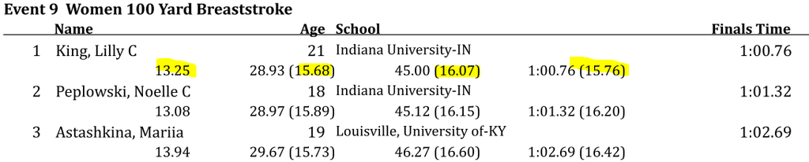

and sometimes by 50 - within the same meet.

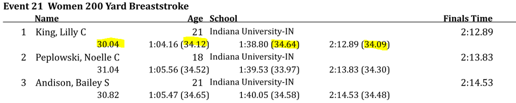

Another example, in [these 2017 Junior National results](https://github.com/gpilgrim2670/Pilgrim_Data/raw/master/SwimmeR%20Demo%20Files/7th-snsc-scm-2017-full-results.pdf) from Singapore, the 1500m splits are by 25 for the first 800m, and then the last split is for the final 700m of the race.

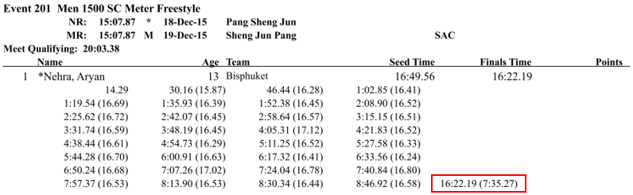

Relays are also traditionally handled differently, with splits summing for individual athletes. In the [2018 Big Ten championship results](https://github.com/gpilgrim2670/Pilgrim_Data/raw/master/SwimmeR%20Demo%20Files/BigTen_WSWIM_2018.pdf) Lilly King does not split a 25.84 on the second 25 of the breaststroke leg of Indiana’s 200 medley relay, rather 25.84 was her time for the entire 50 yard breaststroke leg.

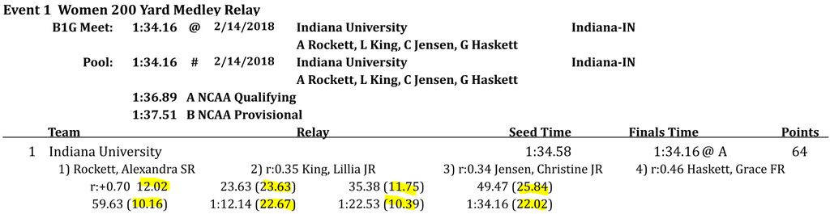

Just be forewarned - splits, even within the same meet, will often require some after-import attention and swimming-specific knowledge to clean.

## Formatting Splits

The preferred format for splits is “lap” format, where each split is the duration of a single lap (or length) of the pool. Splits are sometimes also presented in cumulative format, where each split is the total time elapsed at a particular point in the race. For example consider this data frame, containing two swimmers swimming the exact same times and splits, but with one in lap format and the other in cumulative format.

```r
df <- data.frame(
  Place = 1,
  Name = c("Lenore Lap", "Casey Cumulative"),
  Team = rep("KVAC", 2),
  Event = rep("Womens 200 Freestyle", 2),
  Finals = rep("1:58.00", 2),
  Split_50 = rep("28.00", 2),
  Split_100 = c("31.00", "59.00"),
  Split_150 = c("30.00", "1:29.00"),
  Split_200 = c("29.00", "1:58.00")
)

df
```

```
#>   Place             Name Team                Event  Finals Split_50 Split_100
#> 1     1       Lenore Lap KVAC Womens 200 Freestyle 1:58.00    28.00     31.00
#> 2     1 Casey Cumulative KVAC Womens 200 Freestyle 1:58.00    28.00     59.00
#>   Split_150 Split_200
#> 1     30.00     29.00
#> 2   1:29.00   1:58.00
```

Cumulative splits can be converted to lap splits with the `split_to_lap` function.

```r
df %>%
  filter(Name == "Casey Cumulative") %>%
  splits_to_lap()
```

```
#>   Place             Name Team                Event  Finals Split_50 Split_100
#> 1     1 Casey Cumulative KVAC Womens 200 Freestyle 1:58.00    28.00     31.00
#>   Split_150 Split_200
#> 1     30.00     29.00
```

Splits that are already in lap format can be avoided using the `threshold` parameter in `splits_to_lap`. The value is `threshold` is effectively a maximum lap split value. If no swimmer in the data frame will swim a split slower (i.e. greater than) `35.00` then `35.00` makes a good `threshold` value. Failing to set `threshold` in data frames containing both lap and cumulative split times will result in nonsensical splits and warnings from `SwimmeR`.

```r
df %>%
  splits_to_lap(threshold = 35)
```

```
#>   Place             Name Team                Event  Finals Split_50 Split_100
#> 1     1       Lenore Lap KVAC Womens 200 Freestyle 1:58.00    28.00     31.00
#> 2     1 Casey Cumulative KVAC Womens 200 Freestyle 1:58.00    28.00     31.00
#>   Split_150 Split_200
#> 1     30.00     29.00
#> 2     30.00     29.00
```

Converting to cumulative, although not the preferred format, is possible as well with `splits_to_cumulative`.

```r
df %>%
  filter(Name == "Lenore Lap") %>%
  splits_to_cumulative()
```

```
#>   Place       Name Team                Event  Finals Split_50 Split_100
#> 1     1 Lenore Lap KVAC Womens 200 Freestyle 1:58.00    28.00     59.00
#>   Split_150 Split_200
#> 1   1:29.00   1:58.00
```

Similarly, setting `threshold` allows the exclusion of splits that are already in cumulative format. Here `threshold` is a minimum split value.

```r
df %>%
  splits_to_cumulative(threshold = 20)
```

```
#>   Place             Name Team                Event  Finals Split_50 Split_100
#> 1     1       Lenore Lap KVAC Womens 200 Freestyle 1:58.00    28.00     59.00
#> 2     1 Casey Cumulative KVAC Womens 200 Freestyle 1:58.00    28.00     59.00
#>   Split_150 Split_200
#> 1   1:29.00   1:58.00
#> 2   1:29.00   1:58.00
```

# Relay Swimmers

The final argument to `swim_parse` is `relay_swimmers`, which defaults to `FALSE`. Setting `relay_swimmers = TRUE` will cause `swim_parse` to read in the names of relay swimmers for each relay, and add them to the normal `swim_parse` output as columns. I don’t love this, because the result is having individual swimmers as rows, and relay swimmers as columns (because relay swimmers are associated with their particular relay). This is not very tidy, and `SwimmeR` strives to be tidy. Still, the functionality does exist.

```r
TX_FL_IN_df_relay_swimmers <-
  swim_parse(
    read_results(TX_FL_IN_path),
    # typo = c("Indiana  University", ", University of"), # not required in versions >= 0.7.0
    # replacement = c("Indiana University", ""), # not required in versions >= 0.7.0
    relay_swimmers = TRUE
  )

TX_FL_IN_df_relay_swimmers[1:3,]
```

```
#>   Place Name  Age                 Team  Finals DQ Exhibition
#> 1     1 <NA> <NA>   Indiana University 3:36.59  0          0
#> 2     2 <NA> <NA> Texas, University of 3:36.84  0          0
#> 3     3 <NA> <NA> Texas, University of 3:38.75  0          0
#>                         Event Reaction_Time Relay_Swimmer_1 Relay_Swimmer_2
#> 1 Women 400 Yard Medley Relay          <NA>    Morgan Scott      Lilly King
#> 2 Women 400 Yard Medley Relay          <NA>    Claire Adams Olivia Anderson
#> 3 Women 400 Yard Medley Relay          <NA>      Julia Cook   Brooke Hansen
#>   Relay_Swimmer_3 Relay_Swimmer_4
#> 1 Christie Jensen   Shelby Koontz
#> 2     Remedy Rule  Anelise Diener
#> 3     Emily Reese    Joanna Evans
```

It is of course also possible to read in both splits and relay swimmers, by setting both of the relevant arguments to `TRUE`.

# Reading ISL Results

International Swimming League results are technically .pdf files, but they’re formatted very differently, so they have their own special function, `swim_parse_ISL`. Handling of ISL results is otherwise the same, with the file first going to `read_results` and then to `swim_parse_ISL`, returning a data frame.

The `SwimmeR` package’s favorite swimmer, Lilly King, is involved in the ISL. Let’s see what she got up to at this particular meet.

```r
file_url <-
  "https://github.com/gpilgrim2670/Pilgrim_Data/raw/master/ISL/Season_1_2019/ISL_16112019_CollegePark_Day_1.pdf"

if (SwimmeR:::is_link_broken(file_url) == TRUE) {
  warning("External data unavailable")
} else {
  file_read <- read_results(file_url)
  df_ISL <- swim_parse_ISL(file = file_read)
  df_ISL[which(df_ISL$Name == "KING Lilly"), ]

}
```

```
#> # A tibble: 2 × 7
#> # Rowwise:
#>   Place  Lane Name       Team  Finals  Event                              DQ
#>   <dbl> <dbl> <chr>      <chr> <chr>   <chr>                           <dbl>
#> 1     1     8 KING Lilly CAC   29.00   Women's 50m Breaststroke Final      0
#> 2     1     7 KING Lilly CAC   2:17.78 Women's 200m Breaststroke Final     0
```

Two first place finishes for Ms. King - very nice! Otherwise all the normal information is here, place, time, team, event etc. Beginning in the 2020 season ISL starts reporting points in their results, which `swim_parse_ISL` will also read. `swim_parse_ISL` also handles splits and relay swimmers via the arguments `splits` and `relay_swimmers`. All ISL meets thus far have splits at the 50 walls, so there is no `split_length` argument. Otherwise splits and relay swimmers are handled exactly the same way as `swim_parse`, detailed above.

# Formatting Swimming Times

Once results are captured in R as tidy data frames the real fun can begin - but there’s another problem. Times in swimming are recorded as minutes:seconds.hundredth. This is fine when a time is less than a minute, because `59.99` can be of class `numeric` in R, but times greater than or equal to a minute `1:00.00` are stuck as class `character`. `SwimmeR` provides two functions, `sec_format` and `mmss_format` to convert between times as seconds (for doing math), and times as minutes:seconds.hundredths, for swimming-specific display.

```r
data(King200Breast)
King200Breast
```

```
#> # A tibble: 50 × 4
#>    Event      Year      Time    Date
#>    <chr>      <chr>     <chr>   <date>
#>  1 200 Breast Junior    2:02.60 2018-03-17
#>  2 200 Breast Senior    2:02.90 2019-03-23
#>  3 200 Breast Sophomore 2:03.18 2017-03-18
#>  4 200 Breast Freshman  2:03.59 2016-03-19
#>  5 200 Breast Senior    2:03.60 2018-11-17
#>  6 200 Breast Sophomore 2:04.03 2017-02-18
#>  7 200 Breast Junior    2:04.68 2018-02-17
#>  8 200 Breast Senior    2:05.14 2019-02-23
#>  9 200 Breast Junior    2:05.49 2018-03-17
#> 10 200 Breast Freshman  2:05.58 2016-02-20
#> # … with 40 more rows
```

Included in `SwimmeR` is `King200Breast`, containing all Lilly King’s 200 Breaststroke times for her NCAA career. Times recorded as character values, in standard minutes:seconds.hundredth format. We can use `sec_format` to format them as seconds, and `mmss_format` to go back to minutes:seconds.hundredth. Both functions work well with the `tidyverse` packages.

```r
King200Breast <- King200Breast %>%
  dplyr::mutate(Time_sec = sec_format(Time),
         Time_swim_2 = mmss_format(Time_sec))
King200Breast
```

```
#> # A tibble: 50 × 6
#>    Event      Year      Time    Date       Time_sec Time_swim_2
#>    <chr>      <chr>     <chr>   <date>        <dbl> <chr>
#>  1 200 Breast Junior    2:02.60 2018-03-17     123. 2:02.60
#>  2 200 Breast Senior    2:02.90 2019-03-23     123. 2:02.90
#>  3 200 Breast Sophomore 2:03.18 2017-03-18     123. 2:03.18
#>  4 200 Breast Freshman  2:03.59 2016-03-19     124. 2:03.59
#>  5 200 Breast Senior    2:03.60 2018-11-17     124. 2:03.60
#>  6 200 Breast Sophomore 2:04.03 2017-02-18     124. 2:04.03
#>  7 200 Breast Junior    2:04.68 2018-02-17     125. 2:04.68
#>  8 200 Breast Senior    2:05.14 2019-02-23     125. 2:05.14
#>  9 200 Breast Junior    2:05.49 2018-03-17     125. 2:05.49
#> 10 200 Breast Freshman  2:05.58 2016-02-20     126. 2:05.58
#> # … with 40 more rows
```

This is useful for comparing times, or plotting

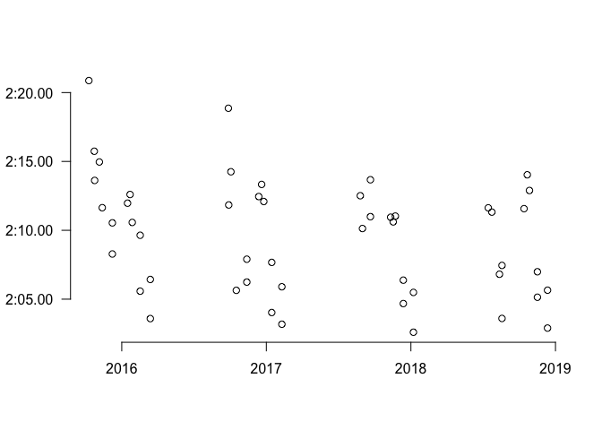

```r
plot(King200Breast$Date, King200Breast$Time_sec, axes = FALSE, ann = FALSE)
axis(1, at = c(16800, 17200, 17600, 18000), labels = c(2016, 2017, 2018, 2019))
axis(2, at = c(125, 130, 135, 140), labels = mmss_format(c(125, 130, 135, 140)), las = 1)
```

```r
par(mar = c(5,7,4,2) + 0.3)
```

The same thing can be done in `ggplot`.

```r
King200Breast %>%
  ggplot(aes(x = Date, y = Time_sec)) +
  geom_point() +
  scale_y_continuous(labels = scales::trans_format("identity", mmss_format)) +
  theme_classic() +
  labs(y= "Time",
       title = "Lilly King NCAA 200 Breaststroke")
```

[output not shown]

# Using `get_mode` to clean swimming data

Swim teams often have abbreviations, for example Lilly King swam for Indiana University, and sometimes “Indiana University” was listed as her team name. Other times though the team might be listed as “IU” or “IUWSD”. James (Sulley) Sullivan swam (probably) for Monsters University, or MU Regularizing these names is a useful part of cleaning data.

```r
Name <- c(rep("Lilly King", 5), rep("James Sullivan", 3))
Team <- c(rep("IU", 2), "Indiana", "IUWSD", "Indiana University", rep("Monsters University", 2), "MU")
df <- data.frame(Name, Team, stringsAsFactors = FALSE)
df
```

```
#>             Name                Team
#> 1     Lilly King                  IU
#> 2     Lilly King                  IU
#> 3     Lilly King             Indiana
#> 4     Lilly King               IUWSD
#> 5     Lilly King  Indiana University
#> 6 James Sullivan Monsters University
#> 7 James Sullivan Monsters University
#> 8 James Sullivan                  MU
```

Lilly has 4 different teams, but all of them are actually the same team. Similarly Sulley has two teams, but actually only one. Using `get_mode` to return the most frequently occurring team for each swimmer is easier than manually specifying every swimmer’s team.

```r
df <- df %>%
  dplyr::group_by(Name) %>%
  dplyr::mutate(Team = get_mode(Team))
df
```

```
#> # A tibble: 8 × 2
#> # Groups:   Name [2]
#>   Name           Team
#>   <chr>          <chr>
#> 1 Lilly King     IU
#> 2 Lilly King     IU
#> 3 Lilly King     IU
#> 4 Lilly King     IU
#> 5 Lilly King     IU
#> 6 James Sullivan Monsters University
#> 7 James Sullivan Monsters University
#> 8 James Sullivan Monsters University
```

# Drawing brackets

To aid in making single elimination brackets for tournaments and shoot-outs `SwimmeR` has `draw_bracket`. Any number of teams between 5 and 64 can be used, with byes automatically assigned to higher seeds.

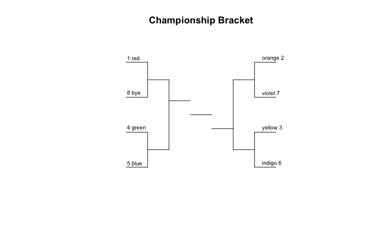

```r
teams <- c("red", "orange", "yellow", "green", "blue", "indigo", "violet")
draw_bracket(teams = teams)
```

Now add the results of round two:

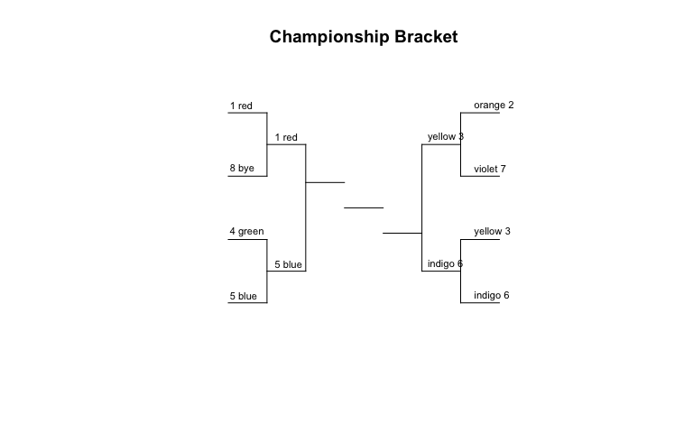

```r
round_two <- c("red", "yellow", "blue", "indigo")
draw_bracket(teams = teams,
             round_two = round_two)
```

And round three:

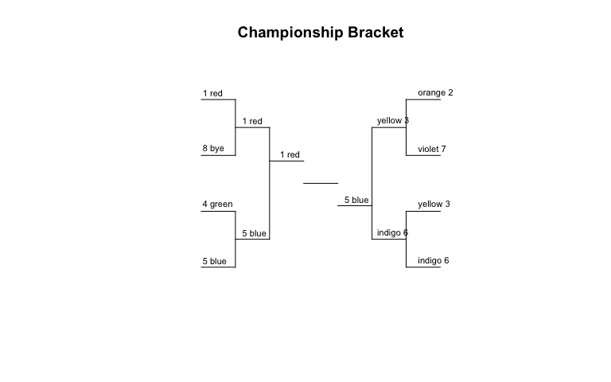

```r
round_three <- c("red", "blue")
draw_bracket(teams = teams,
             round_two = round_two,
             round_three = round_three)
```

And crown the champion:

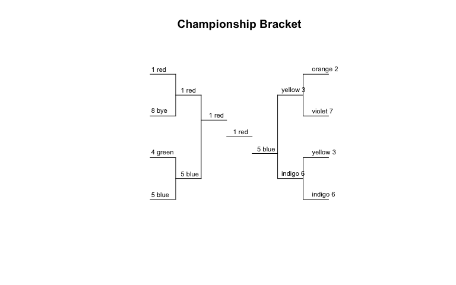

```r
champion <- "red"
draw_bracket(teams = teams,
             round_two = round_two,
             round_three = round_three,
             champion = champion)
```